# Project 1: Wrangling, Exploration, Visualization

SDS322E

## Data Wrangling, Exploration, Visualization

### Mark Kazmierczak, mjk2299

#### Introduction

For Project 1 I worked with 2 data sets containing data about NFL All-Pro Players and teams salary distributions. One data set I collected was the combined rosters of the All-Pro Teams between the years 2015-2020. This dataset contained a lot of player specific data that would not be used, but also included the number of players from each team and year that were selected to the All-Pro Team. The other dataset that I used was one that I created in SDS 328 that included the percentage of the salary cap that an NFL team paid to its highest paid player and to all of its players on rookie contracts, along with the number of regular season games that team won. I decided to use these data sets because I thought it would be interesting to look at the impacts that All-Pro players have on the success of an NFL team as well as the impact of the distribution of salary.

```r
library(tidyverse)
library(knitr)
data1 <- read_csv("~/project1/All_pro.csv")
data2 <- read_csv("~/project1/Salary_cap.csv")
```

#### Tidying: Reshaping

If your datasets are tidy already, demonstrate that you can reshape data with pivot wider/longer here (e.g., untidy and then retidy). Alternatively, it may be easier to wait until the wrangling section so you can reshape your summary statistics. Note here if you are going to do this.

```r
# Pivot wider from data1
wide_data1 <- data1 %>% pivot_wider(values_from = c(Tm), names_from = c(Year))

head(wide_data1)
```

```
## # A tibble: 6 x 26
##   Pos   Player Yrs       G    GS   Cmp   Att   Yds    TD   Int Att_1 Yds_1  TD_1
##   <chr> <chr>  <chr> <dbl> <dbl> <dbl> <dbl> <dbl> <dbl> <dbl> <dbl> <dbl> <dbl>
## 1 QB    Cam N… 4        16    16   296   495  3837    35    10   132   636    10
## 2 QB    Carso… 11       16    16   342   537  4671    35    11    25    24     1
## 3 QB    Tom B… 15       16    16   402   624  4770    36     7    34    53     3
## 4 RB    Doug … 3        16    16     0     0     0     0     0   288  1402     6
## 5 RB    Adria… 8        16    16     0     0     0     0     0   327  1485    11
## 6 RB    Chris… 5        15    14     0     0     0     0     0   247  1070     7
## # … with 13 more variables: Rec <dbl>, Yds_2 <dbl>, TD_2 <dbl>, Solo <dbl>,
## #   Sk <dbl>, Int_1 <dbl>, `All-pro teams` <chr>, `2015` <chr>, `2016` <chr>,
## #   `2017` <chr>, `2018` <chr>, `2019` <chr>, `2020` <chr>
```

```r
# Pivot back to long
longdata1 <- wide_data1 %>% pivot_longer(21:26, names_to = "year",
    values_to = "Team") %>% na.omit()

head(longdata1)
```

```
## # A tibble: 6 x 22
##   Pos   Player Yrs       G    GS   Cmp   Att   Yds    TD   Int Att_1 Yds_1  TD_1
##   <chr> <chr>  <chr> <dbl> <dbl> <dbl> <dbl> <dbl> <dbl> <dbl> <dbl> <dbl> <dbl>
## 1 QB    Cam N… 4        16    16   296   495  3837    35    10   132   636    10
## 2 QB    Carso… 11       16    16   342   537  4671    35    11    25    24     1
## 3 QB    Tom B… 15       16    16   402   624  4770    36     7    34    53     3
## 4 RB    Doug … 3        16    16     0     0     0     0     0   288  1402     6
## 5 RB    Adria… 8        16    16     0     0     0     0     0   327  1485    11
## 6 RB    Chris… 5        15    14     0     0     0     0     0   247  1070     7
## # … with 9 more variables: Rec <dbl>, Yds_2 <dbl>, TD_2 <dbl>, Solo <dbl>,
## #   Sk <dbl>, Int_1 <dbl>, `All-pro teams` <chr>, year <chr>, Team <chr>
```

#### Joining/Merging

```r
# Clean up Data 1: Create a teamID for each team/year and
# make into new column for number of All-Pros on each team
data1clean <- data1 %>% separate(Year, into = c("century", "year"),
    sep = 2) %>% unite(Tm, year, col = "teamID", sep = "_") %>%
    group_by(teamID) %>% summarise(n()) %>% rename(all_pros = "n()")

head(data1clean)
```

```
## # A tibble: 6 x 2
##   teamID all_pros
##   <chr>     <int>
## 1 2TM_18        1
## 2 2TM_19        2
## 3 ARI_15        6
## 4 ARI_16        3
## 5 ARI_17        2
## 6 ARI_18        1
```

```r
# data1 distinct observation

data1clean %>% summarise(n_distinct(teamID))
```

```
## # A tibble: 1 x 1
##   `n_distinct(teamID)`
##                  <int>
## 1                  174
```

```r
# Clean up Data 2: Make the teamID match data1
data2clean <- data2 %>% separate(Team, into = c("year", "team")) %>%
    unite(team, year, col = "teamID", sep = "_")

head(data2clean)
```

```
## # A tibble: 6 x 4
##   teamID `% salary cap to highest… `% salary cap to players o… `Regular Season …
##   <chr>                      <dbl>                       <dbl>             <dbl>
## 1 CIN_15                      9.7                         18.2                12
## 2 DEN_15                     11.7                         15.0                12
## 3 ARI_15                      9.96                        17.3                13
## 4 MIA_15                      7.01                        17.4                 6
## 5 JAX_15                      6.11                        26.2                 5
## 6 DET_15                     14.2                         18.3                 7
```

```r
# data2 distinct observation

data2clean %>% summarise(n_distinct(teamID))
```

```
## # A tibble: 1 x 1
##   `n_distinct(teamID)`
##                  <int>
## 1                   60
```

```r
# Left Merge
merged_data <- left_join(data2clean, data1clean)

head(merged_data)
```

```
## # A tibble: 6 x 5
##   teamID `% salary cap to hig… `% salary cap to play… `Regular Season … all_pros
##   <chr>                  <dbl>                  <dbl>             <dbl>    <int>
## 1 CIN_15                  9.7                    18.2                12        4
## 2 DEN_15                 11.7                    15.0                12        2
## 3 ARI_15                  9.96                   17.3                13        6
## 4 MIA_15                  7.01                   17.4                 6        4
## 5 JAX_15                  6.11                   26.2                 5        1
## 6 DET_15                 14.2                    18.3                 7        1
```

In order to merge the two dataset I first had to create a unique identifier for each team. This identifier consisted of the three letter abbreviation for the team followed by an underscore and then a two digit code for the year. For instance the 2019 Green Bay Packers would be coded as “GNB_19”. For dataset1 I accomplished this by first separating the “Year” into “century” and “year”. I was then able to unite “Tm” and “year” variables and separate them by an underscore to create the “teamID” variable. With a “teamID” variable created I could now group by this variable and use the n() function to count the number of rows for each “teamID”. The number of rows for each team was equal to the number of All-Pros on that given team. This column was then renamed “all_pros” and this dataset would be merged with data2.

Both datasets were tidy so I practiced pivoting the original data1 wide and then back long.

#### Wrangling

```r
# Count the NAs
merged_data %>% summarise(sum(is.na(.)))
```

```
## # A tibble: 1 x 1
##   `sum(is.na(.))`
##             <int>
## 1               8
```

```r
# Replace NA with 0s
merged_data <- merged_data %>% replace(is.na(.), 0)

# Add 'Winning_Season' column with mutate
merged_data <- merged_data %>% mutate(season_result = ifelse(`Regular Season wins` >
    8.1, "winning", "losing"))

# Add ratio paid to highest paid: Rookie Contracts
merged_data <- merged_data %>% mutate(Highest_Rookie_Ratio = `% salary cap to highest paid player`/`% salary cap to players on rookie contracts`)

glimpse(merged_data)
```

```
## Rows: 61
## Columns: 7
## $ teamID                                        <chr> "CIN_15", "DEN_15", "AR…
## $ `% salary cap to highest paid player`         <dbl> 9.70, 11.66, 9.96, 7.01…
## $ `% salary cap to players on rookie contracts` <dbl> 18.22, 15.03, 17.30, 17…
## $ `Regular Season wins`                         <dbl> 12.0, 12.0, 13.0, 6.0, …
## $ all_pros                                      <int> 4, 2, 6, 4, 1, 1, 1, 2,…
## $ season_result                                 <chr> "winning", "winning", "…
## $ Highest_Rookie_Ratio                          <dbl> 0.5323820, 0.7757818, 0…
```

```r
# Mean 'Highest_Rookie_Ratio' for winning season vs losing
# season
merged_data %>% group_by(season_result) %>% summarise(mean(Highest_Rookie_Ratio)) %>%
    kable()
```

| season_result | mean(Highest_Rookie_Ratio) |
| --- | --- |
| losing | 0.4870258 |
| winning | 0.6608650 |

```r
# Median number of All-Pros for winning season vs losing
# season
merged_data %>% group_by(season_result) %>% summarise(median(all_pros)) %>%
    kable()
```

| season_result | median(all_pros) |
| --- | --- |
| losing | 1.0 |
| winning | 3.5 |

```r
# 3 Losing teams with the most All-Pros
merged_data %>% filter(season_result == "losing") %>% arrange(-all_pros) %>%
    select(teamID, `Regular Season wins`, all_pros) %>% head(3) %>%
    kable()
```

| teamID | Regular Season wins | all_pros |
| --- | --- | --- |
| TAM_19 | 7 | 5 |
| MIA_15 | 6 | 4 |
| LAR_16 | 4 | 4 |

```r
# Detect Teams with a Tie
merged_data %>% filter(str_detect(`Regular Season wins`, "[\\.]5")) %>%
    select(teamID, `Regular Season wins`) %>% kable()
```

| teamID | Regular Season wins |
| --- | --- |
| SEA_16 | 10.5 |
| GNB_18 | 7.5 |
| MIN_18 | 8.5 |
| ARI_19 | 5.5 |
| DET_19 | 3.5 |
| CIN_20 | 4.5 |

```r
# Table of Winning vs Losing Season

merged_data %>% group_by(season_result) %>% summarise(n()) %>%
    kable()
```

| season_result | n() |
| --- | --- |
| losing | 37 |
| winning | 24 |

```r
# mean wins for teams that pay the highest paid player than
# all rookie contracts
merged_data %>% filter(`% salary cap to highest paid player` >
    `% salary cap to players on rookie contracts`) %>% summarise(mean(`Regular Season wins`))
```

```
## # A tibble: 1 x 1
##   `mean(\`Regular Season wins\`)`
##                             <dbl>
## 1                             8.5
```

```r
# Max percent paid to top earner on teams with more than 10
# wins
merged_data %>% group_by(all_pros > median(all_pros), season_result) %>%
    summarise(mean(`% salary cap to highest paid player`)) %>%
    kable()
```

| all_pros > median(all_pros) | season_result | mean(`% salary cap to highest paid player`) |
| --- | --- | --- |
| FALSE | losing | 8.770645 |
| FALSE | winning | 9.774000 |
| TRUE | losing | 8.906667 |
| TRUE | winning | 10.430000 |

```r
# Max percent paid to rookies on teams with more than 10 wins
merged_data %>% group_by(`Regular Season wins` > 10) %>% summarise(mean(`% salary cap to players on rookie contracts`)) %>%
    kable()
```

| `Regular Season wins` > 10 | mean(`% salary cap to players on rookie contracts`) |
| --- | --- |
| FALSE | 18.65917 |
| TRUE | 14.86462 |

Before manipulating the merged_data set I used summarize function to count the number of NAs present in the dataset. These NAs represented teams that had no All-Pros on the roster. The replace function was used to replaces the NAs with 0. I then wanted to create a categorical variable describing whether or not the team had a winning season. This was done by creating a new column using the mutate function and then using the ifelse function to separate teams that either won more than eight games (“winning”) or won eight or less games (“losing”). The final variable that was created was ratio of single highest paid player pay to the pay of all of the rookie contracts.

#### Visualizing

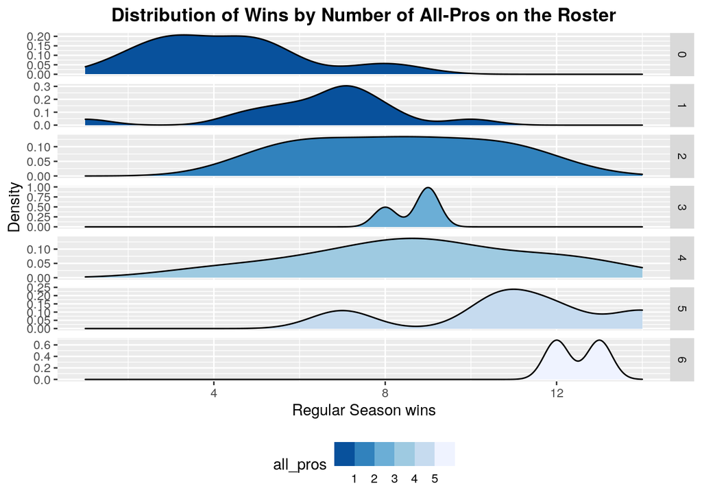

```r
# Plot 1: Win Distributions
merged_data %>% ggplot(aes(x = `Regular Season wins`, fill = all_pros)) +
    geom_density() + facet_grid(all_pros ~ ., scales = "free_y") +
    scale_x_continuous(breaks = seq(0, 16, 4)) + ylab("Density") +
    ggtitle("Distribution of Wins by Number of All-Pros on the Roster") +
    theme(plot.title = element_text(hjust = 0.5, face = "bold")) +
    theme(legend.position = "bottom") + scale_fill_fermenter()
```

To visualize the effect of having All-Pros on a roster has on the teams record I created this density plot. I filled the plot by the all_pros variable and faceted the plot so that each groups could be independently observed. On teams with on 0-1 All-Pros the distribution of wins is mostly less than 8. Teams with 2-4 All-Pros saw in increase in the number of wins and were more evenly distributed around the 8 win mark. This trend of increasing with the increasing number of players continued on teams that had with 5-6 players. Most of these teams had well over 8 wins. It is important to note the the Y axis is scaled independently. Although this changes the values on the Y axis for each graph, it makes it easier to observe the effect that All-Pros have of the distribution of wins.

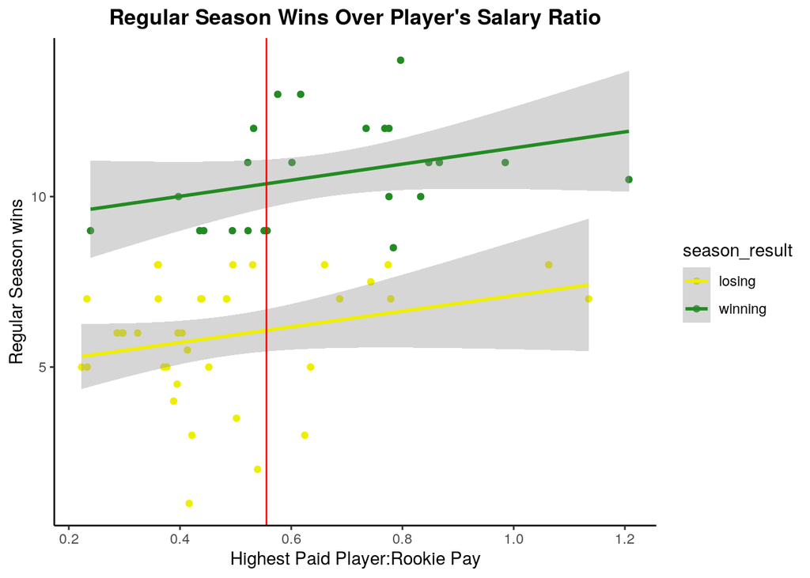

```r
# Plot 2: Wins over the ratio of single player to rookie
# contracts salary

merged_data %>% ggplot(aes(x = Highest_Rookie_Ratio, y = `Regular Season wins`,
    col = season_result)) + geom_point(size = 1.5) + geom_smooth(method = "lm") +
    geom_vline(xintercept = mean(merged_data$Highest_Rookie_Ratio),
        col = "red") + scale_x_continuous(breaks = seq(0, 1.2,
    0.2)) + xlab("Highest Paid Player:Rookie Pay") + ggtitle("Regular Season Wins Over Player's Salary Ratio") +
    scale_color_manual(values = c(losing = "yellow2", winning = "forestgreen")) +
    theme_classic() + theme(plot.title = element_text(hjust = 0.5,
    face = "bold"))
```

In this graph I looked at the relationship between regular season wins and the pay ratio variable that was created. To create this graph merged_data was group by the result of the season and then then number of wins was plotted against the pay ratio. A trend line was added using a linear model. A red vertical line was added to represent the average ratio. For both teams with losing and winning records there appeared to be a slight and similar positive relationship between these variables. With the red vertical line we can also observe that most teams with a losing record have a pay ratio less than the average ratio, while most teams with a winning record have an above average pay ratio. This relationship suggests that paying individual star players a high ratio of the salary compared to rookies can have a positive effect on the total number of wins.

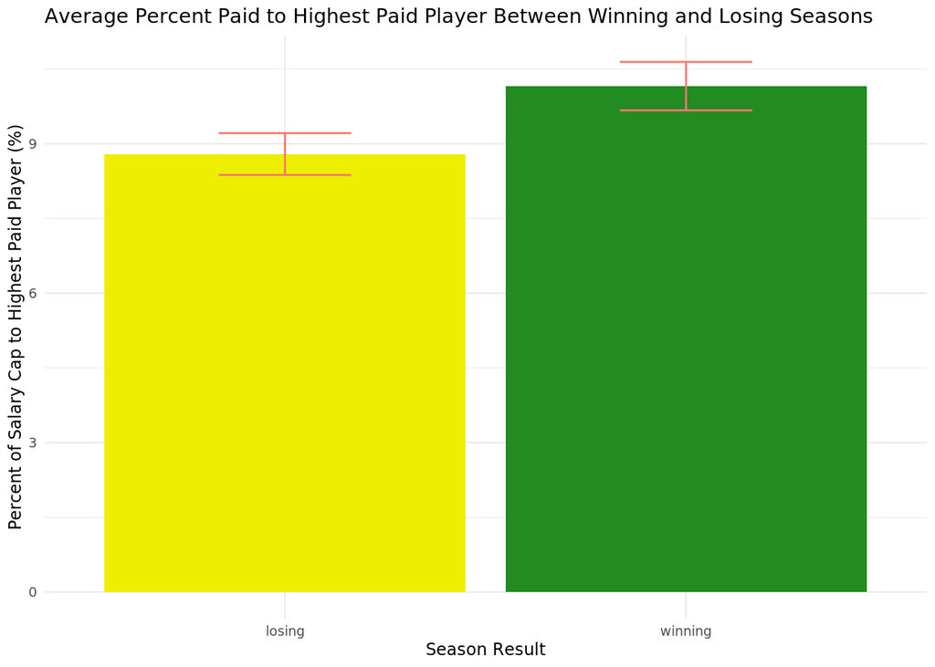

```r
# Plot3: Average Percent Paid to single highest paid player
# between teams with losing and winning records
merged_data %>% ggplot(aes(x = season_result, y = `% salary cap to highest paid player`,
    fill = season_result)) + geom_bar(stat = "summary", fun = mean) +
    xlab("Season Result") + ylab("Percent of Salary Cap to Highest Paid Player (%)") +
    ggtitle("Average Percent Paid to Highest Paid Player Between Winning and Losing Seasons") +
    scale_y_continuous(breaks = seq(0, 15, 3)) + geom_errorbar(stat = "summary",
    fun.data = mean_se, width = 0.33, aes(color = "red")) + scale_fill_manual(values = c(losing = "yellow2",
    winning = "forestgreen")) + theme_minimal(base_family = "bold",
    base_size = 9) + theme(legend.position = "none ")
```

I created a bar chart with error bars with only the percentage paid to the highest paid player variable instead of the ratio variable. I was looking to see if there was a continuation of the trend between total wins and the highest paid player to rookie contract ratio would be observed when looking at only the highest paid player percentage. Once again I grouped by the result of the season and then compared percent of salary each group paid to the highest earning player. As expected after observing the trend in Plot 2, it appeared that teams with winning records paid their star players a higher percentage of the salary cap. This helps explain the relationship observed in plot 2, but a similar plot with percent of salary cap to rookie contracts in combination with this graph would better help us visualize the effect each of these two variable has in determining the relationship observed in Plot 2.